# Osmose Simulations

Ernesto Carrella

November 13, 2015

A few results of what happens when I tie our current model to a real ecosystem model.

Here are a few runs in OSMOSE with the default configuration : it has about 15 species interacting.

## Pathfinding

One problem with non cartoonish maps such as the ones in OSMOSE is that boats need to be relatively smart about avoid land. Also, in a model where speed and timing matters such as ours, we need agents to go from A to B in the best way possible. We used to ignore this and have boats just cruise over land, but apparently some didn’t find that realistic.  
The current version of the model implements a shiny A* algorithm for pathfinding.

[figure not shown]

## Fishing Fronts

In our data-free model boats kill off fish progressively farther from port. This effect is weaker in OMSMOSE because spawning is distributed uniformly across the ocean so that even though fishers can annhilate fish on one side of the map the offspring of the survivors on the other side of the map will spawn everywhere. Fishers then can just keep catching close to port.

[figure not shown]

## MPAs

Yesterday night (UK time) we talked about MPAs and how fishing the line might not emerge if the biological rules differ. OSMOSE, I mentioned, is a good example of this: because fish tends to be concentrated in schools rather than disperse uniformly fishing precisely on the border isn’t a winning strategy, altough fishing somewhat in the proximity still is.

[figure not shown]

## Ebbs and Flows

Imagine fishers have 2 kinds of gear available to them: gear that catch only Demersal fish of type 1 or Demersal fish of type 2. Basically fishers have to choose their target species.

Because our fishers are quite overpowered (that is, they have high catchability) if they concentrate on a species they tend to kill it pretty efficiently. With enough killing it becomes profitable to switch to target a different kind of fish. In OSMOSE this makes fishers switch gear about every 10 year.

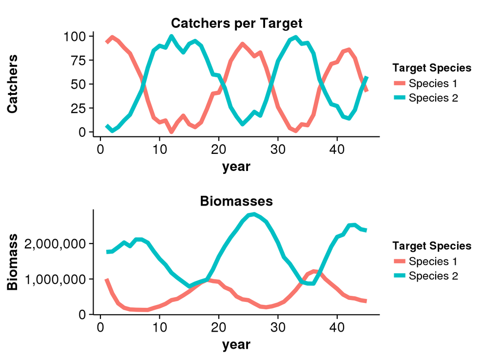

## Biomass interaction

One thing that ecosystem models are supposed to do is to predict the effects of fishing one species with regard to all the others.  
To show OSMOSE contribution I ran the model 50 times under 3 different conditions:

A. No fisher  
B. Fishers only catch “Demersal1” kind of fish  
C. Fishers only catch “Demersal2” kind of fish

Moreover I kept track of the biomass of three different species through these scenarios:

1. Mesopelagic fish (who is never targeted)
2. Demersal1 which is caught in scenario B
3. Demersal2 which is caught in scenario C

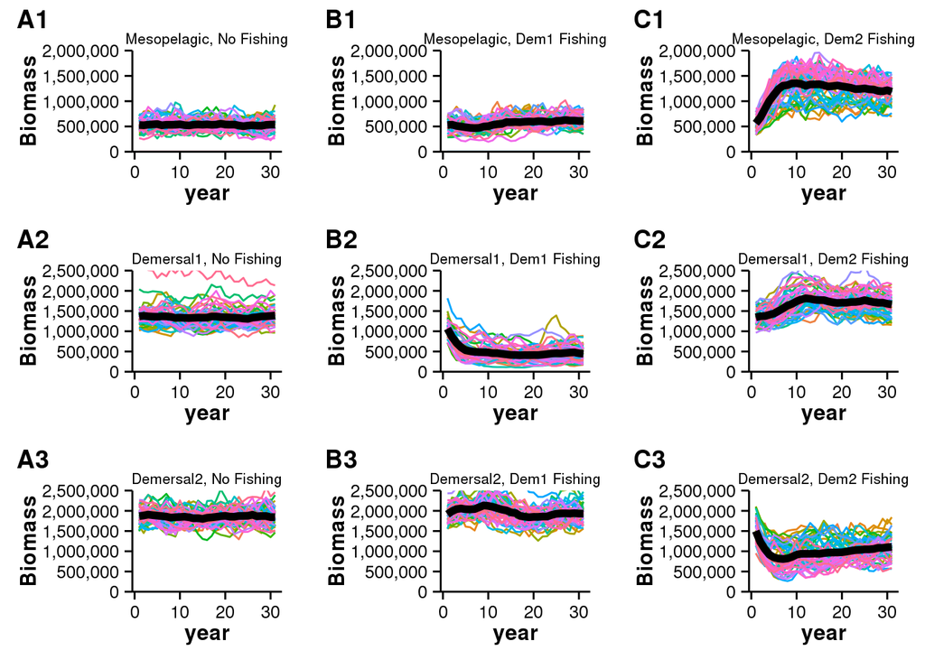

First of all, plot B2 and C3 show how fishing out the targeted species has a strong effect on the biomass available. Fishing kills fish, you hear it here first!  
The most interesting result is probably plot C1-C2 though. Mesopelagic fish is never affected directly by fishing, but when large amount of Demersal2 fish die, both Mesopelagic and Demersal1 fish experience a boom. These are strong results and they will matter when setting policy.